# Part II - Ford GoBike System Data

## by Joy James

## Investigation Overview

In this analysis, I explored the Ford GoBike system to understand what factors influence the duration of the trip. I primarily looked at the distance covered, the time of the day the trip was taken as well as the age and gender of the riders.

## Dataset Overview

The original dataset contained about 183,412 observations across 16 variables. Most of the variables speak to details about the trip itself and a few such as age and gender describe the rider. In the course of the analysis, new features were derived from existing ones. Also, outliers from the trip duration were also dropped.

## How long does it take the riders to complete trips?

The trips range between 61 seconds (~ 1 mintue) to about 4,000 seconds ( ~ 1 hour) long. However this excludes the outliers which can be as high as 86,000 seconds (~ 24 hours) long. Plotting this on a logarithmic scale, the trip duration has a near normal distribution with a single peak at about 500 seconds ( ~ 8 minutes).

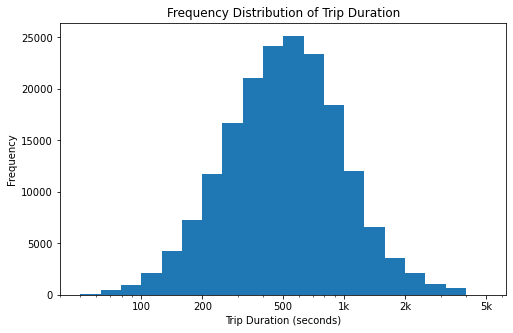

## What distance is covered during these trips?

For some trips, no distance is covered at all (0km). But for some others, they cover as much as 15 km or more. After excluding outliers and plotting on a logarithmic scale, it can be seen that most trips are between 1 to 2 kilometers wrong.

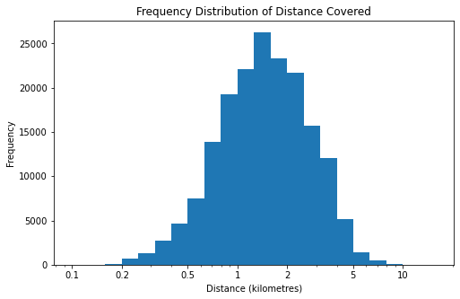

## What time of the day do riders prefer to take their trips?

From the graph above, it is seen that people would rather take their trips in the evening or morning. Fewer people take trips at mid day and even fewer people ride at night or early in the morning.

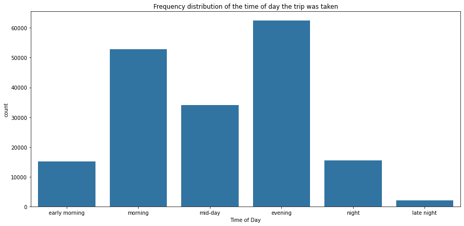

## How does the trip duration vary with the distance covered?

As the distance increases, there is a slight increase in trip duration. Also, some riders seem to rent bikes but never leave the station. This is explained by the straight line at 0km as seen in the next visual.

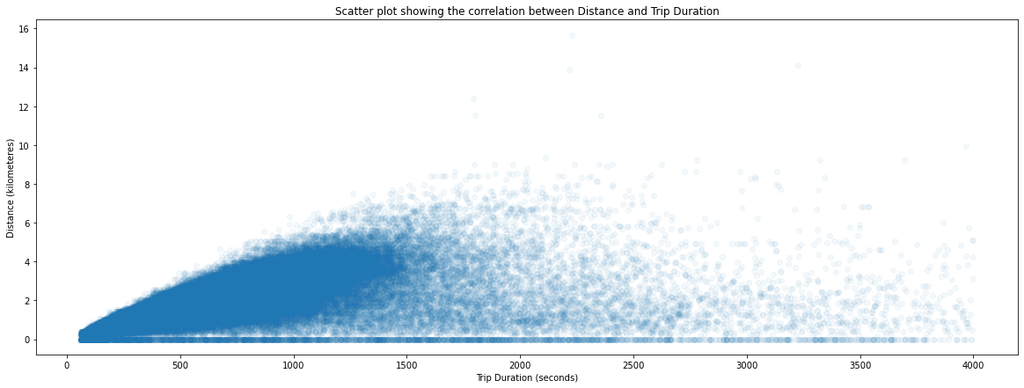

## How does the time taken to cover the same distance vary with the time of the day?

The correlation between distance and duration is approximately the same for all times of the day. However, as the day progresses to the evening, more time is taken to cover the same distance. But as night comes, the duration decreases for the same distance.

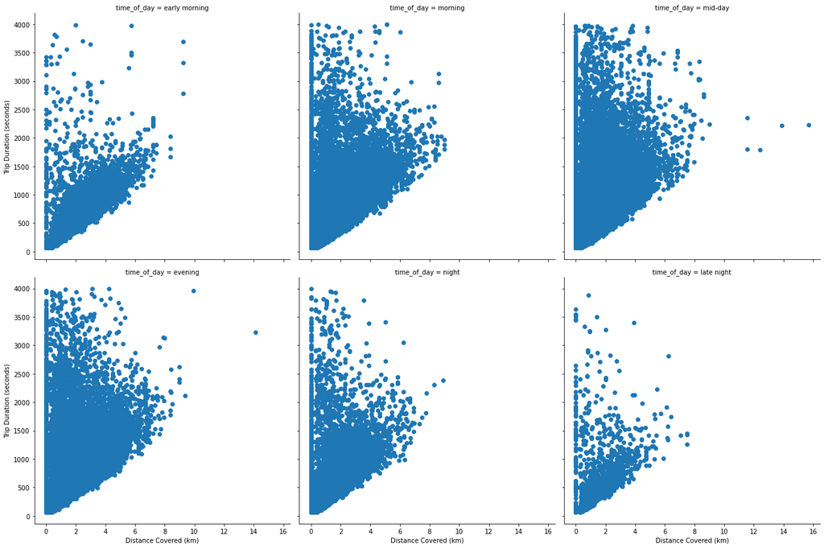